# CourseProject

YuWang

2017/8/20

## Load and Clean Data

First we load the data from the csv files. Then we take a look at the data and try to extract possibly useful features.

```r
oriData <- read.csv("https://d396qusza40orc.cloudfront.net/predmachlearn/pml-training.csv")
testfinal <- read.csv("https://d396qusza40orc.cloudfront.net/predmachlearn/pml-testing.csv")
```

It seems that the first several columns have no impact on the classe variable, so we can remove these variables.

```r
oriData[, 1:7] <- NULL
```

Also we can find that some of the features are mostly blanks/NAs or have nearly zero variance, so we also remove these features.

```r
library(caret)
library(gbm)
nzv <- nearZeroVar(oriData, saveMetrics=TRUE)
oriData <- oriData[,nzv$nzv==FALSE]

isNACnt <- sapply(oriData, function(x) sum(is.na(x)))
oriData[, isNACnt > dim(oriData)[1] * 0.7] <- NULL
```

Then we separate the original data into training set, testing set and cross validation set.

```r
inTrain <- createDataPartition(oriData$classe, p=0.6, list=FALSE)
myTraining <- oriData[inTrain, ]
myTesting <- oriData[-inTrain, ]
inTest <- createDataPartition(myTesting$classe, p=0.5, list=FALSE)
myCV <- myTesting[-inTest, ]
myTesting <- myTesting[inTest, ]
```

## Build the model

We use the trainControl function to set options for the model. Then we try different models to see which one performs well in cross validation.

### Random Forests

```r
library(randomForest)
set.seed(666)
modRF <- randomForest(classe ~., data = myTraining)
predictionRF <- predict(modRF, newdata = myTesting, type = "class")
CMRF <- confusionMatrix(predictionRF, myTesting$classe)
CMRF
```

```
## Confusion Matrix and Statistics
##
##           Reference
## Prediction    A    B    C    D    E
##          A 1116    1    0    0    0
##          B    0  757    4    0    0
##          C    0    1  679   12    1
##          D    0    0    1  631    2
##          E    0    0    0    0  718
##
## Overall Statistics
##
##                Accuracy : 0.9944
##                  95% CI : (0.9915, 0.9965)
##     No Information Rate : 0.2845
##     P-Value [Acc > NIR] : < 2.2e-16
##
##                   Kappa : 0.9929
##  Mcnemar's Test P-Value : NA
##
## Statistics by Class:
##
##                      Class: A Class: B Class: C Class: D Class: E
## Sensitivity            1.0000   0.9974   0.9927   0.9813   0.9958
## Specificity            0.9996   0.9987   0.9957   0.9991   1.0000
## Pos Pred Value         0.9991   0.9947   0.9798   0.9953   1.0000
## Neg Pred Value         1.0000   0.9994   0.9985   0.9964   0.9991
## Prevalence             0.2845   0.1935   0.1744   0.1639   0.1838
## Detection Rate         0.2845   0.1930   0.1731   0.1608   0.1830
## Detection Prevalence   0.2847   0.1940   0.1767   0.1616   0.1830
## Balanced Accuracy      0.9998   0.9981   0.9942   0.9902   0.9979
```

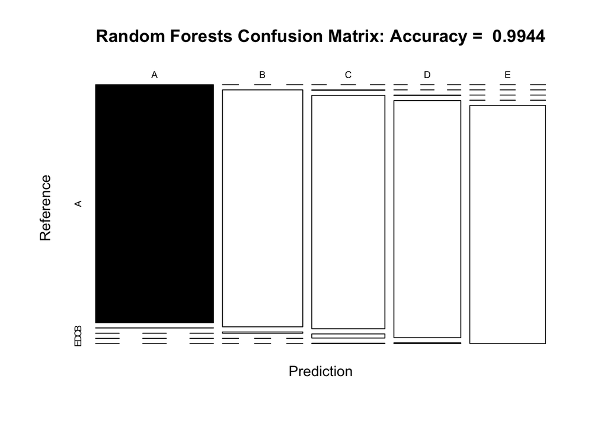

```r
plot(CMRF$table, col = CMRF$byClass, main = paste("Random Forests Confusion Matrix: Accuracy = ", round(CMRF$overall['Accuracy'], 4)))
```

### Decision Trees

```r
library(rpart)
set.seed(666)
modDT <- rpart(classe ~ ., data = myTraining, method = "class")
predictionDT <- predict(modDT, newdata = myTesting, type = "class")
CMDT <- confusionMatrix(predictionDT, myTesting$classe)
CMDT
```

```
## Confusion Matrix and Statistics
##
##           Reference
## Prediction   A   B   C   D   E
##          A 922  83   9  52  40
##          B  48 522  60  31  38
##          C  52 102 555 119  99
##          D  80  44  27 384  33
##          E  14   8  33  57 511
##
## Overall Statistics
##
##                Accuracy : 0.7377
##                  95% CI : (0.7236, 0.7514)
##     No Information Rate : 0.2845
##     P-Value [Acc > NIR] : < 2.2e-16
##
##                   Kappa : 0.6685
##  Mcnemar's Test P-Value : < 2.2e-16
##
## Statistics by Class:
##
##                      Class: A Class: B Class: C Class: D Class: E
## Sensitivity            0.8262   0.6877   0.8114  0.59720   0.7087
## Specificity            0.9344   0.9441   0.8851  0.94390   0.9650
## Pos Pred Value         0.8336   0.7468   0.5987  0.67606   0.8202
## Neg Pred Value         0.9311   0.9265   0.9569  0.92280   0.9364
## Prevalence             0.2845   0.1935   0.1744  0.16391   0.1838
## Detection Rate         0.2350   0.1331   0.1415  0.09788   0.1303
## Detection Prevalence   0.2819   0.1782   0.2363  0.14479   0.1588
## Balanced Accuracy      0.8803   0.8159   0.8483  0.77055   0.8369
```

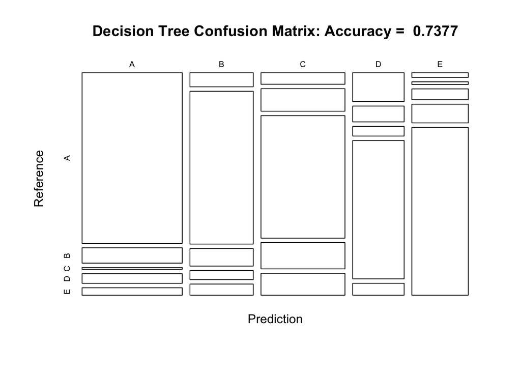

```r
plot(CMDT$table, col = CMDT$byClass, main = paste("Decision Tree Confusion Matrix: Accuracy = ", round(CMDT$overall['Accuracy'], 4)))
```

### Generalized Boosted Regression

```r
set.seed(666)
modGBM <- train(classe ~ ., data = myTraining, method = "gbm",
             trControl = trainControl(method = "repeatedcv", number = 5, repeats = 1),
             verbose = FALSE)
predictionGBM <- predict(modGBM, newdata = myTesting)
CMGBM <- confusionMatrix(predictionGBM, myTesting$classe)
CMGBM
```

```
## Confusion Matrix and Statistics
##
##           Reference
## Prediction    A    B    C    D    E
##          A 1096   21    0    0    2
##          B   13  709   30    2    8
##          C    5   29  646   36    8
##          D    2    0    7  600   12
##          E    0    0    1    5  691
##
## Overall Statistics
##
##                Accuracy : 0.9539
##                  95% CI : (0.9468, 0.9602)
##     No Information Rate : 0.2845
##     P-Value [Acc > NIR] : < 2.2e-16
##
##                   Kappa : 0.9416
##  Mcnemar's Test P-Value : 4.461e-07
##
## Statistics by Class:
##
##                      Class: A Class: B Class: C Class: D Class: E
## Sensitivity            0.9821   0.9341   0.9444   0.9331   0.9584
## Specificity            0.9918   0.9832   0.9759   0.9936   0.9981
## Pos Pred Value         0.9794   0.9304   0.8923   0.9662   0.9914
## Neg Pred Value         0.9929   0.9842   0.9881   0.9870   0.9907
## Prevalence             0.2845   0.1935   0.1744   0.1639   0.1838
## Detection Rate         0.2794   0.1807   0.1647   0.1529   0.1761
## Detection Prevalence   0.2852   0.1942   0.1846   0.1583   0.1777
## Balanced Accuracy      0.9869   0.9587   0.9602   0.9634   0.9783
```

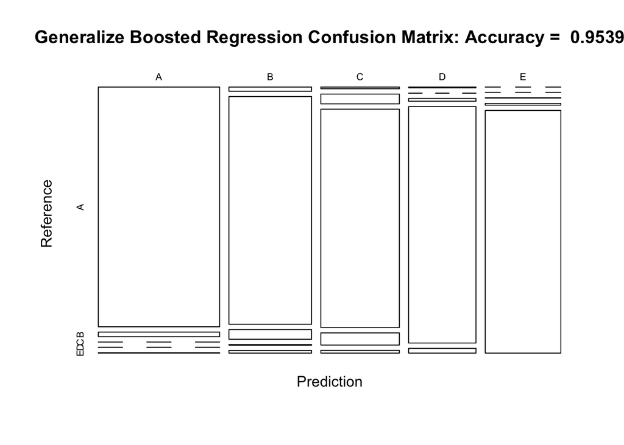

```r
plot(CMGBM$table, col = CMGBM$byClass, main = paste("Generalize Boosted Regression Confusion Matrix: Accuracy = ", round(CMGBM$overall['Accuracy'], 4)))
```

## Estimate Out-of-Sample Error

From above we can see that the accuracy of random forests model is higher than both of decision trees and generalized boosted regression model. Thus we will choose the random forests model to make predictions and use the cross validation dataset to estimate out-of-sample error.

```r
predictionCV <- predict(modRF, newdata = myCV, type = "class")
CMCV <- confusionMatrix(predictionCV, myCV$classe)
CMCV
```

```
## Confusion Matrix and Statistics
##
##           Reference
## Prediction    A    B    C    D    E
##          A 1113    2    0    0    0
##          B    2  755    1    0    0
##          C    1    2  683   11    1
##          D    0    0    0  631    3
##          E    0    0    0    1  717
##
## Overall Statistics
##
##                Accuracy : 0.9939
##                  95% CI : (0.9909, 0.9961)
##     No Information Rate : 0.2845
##     P-Value [Acc > NIR] : < 2.2e-16
##
##                   Kappa : 0.9923
##  Mcnemar's Test P-Value : NA
##
## Statistics by Class:
##
##                      Class: A Class: B Class: C Class: D Class: E
## Sensitivity            0.9973   0.9947   0.9985   0.9813   0.9945
## Specificity            0.9993   0.9991   0.9954   0.9991   0.9997
## Pos Pred Value         0.9982   0.9960   0.9785   0.9953   0.9986
## Neg Pred Value         0.9989   0.9987   0.9997   0.9964   0.9988
## Prevalence             0.2845   0.1935   0.1744   0.1639   0.1838
## Detection Rate         0.2837   0.1925   0.1741   0.1608   0.1828
## Detection Prevalence   0.2842   0.1932   0.1779   0.1616   0.1830
## Balanced Accuracy      0.9983   0.9969   0.9970   0.9902   0.9971
```

```r
OSerror <- as.numeric(1 - CMCV$overall[1])
```

The estimated out-of-sample error is 0.0061178.

## Prediction on 20 test cases

We will use the random forests model to predict the 20 test cases.

```r
predictionFinal <- predict(modRF, newdata = testfinal, type = "class")
predictionFinal
```

```
##  1  2  3  4  5  6  7  8  9 10 11 12 13 14 15 16 17 18 19 20
##  B  A  B  A  A  E  D  B  A  A  B  C  B  A  E  E  A  B  B  B
## Levels: A B C D E
```